# R Notebook

Cargar librerias

```r
suppressMessages({
  library(tidyverse)
  library(Amelia)
  library(ggplot2)
  library(ROCR)
  library(cowplot)
  library(caret)
  library(e1071)
  library(lubridate)
})
```

# Carga y chequeo de datos

Cargar datos – columna X1 sera usada como ID unica

```r
CaudalDF=read_delim(file=unz(description='Data/caudal_extra.csv.zip', filename='caudal_extra.csv'), delim=',')
```

Chequear columnas que no son unicas para eliminar informacion irrelevante. Las columnas institucion y fuentes no varian.

```r
CaudalDF[,which(unlist(lapply(X=CaudalDF, FUN=function(x){
  length(unique(x))
}))==1)]=NULL
```

Investigar estructura de la tabla

```r
str(CaudalDF)
```

```
## Classes 'spec_tbl_df', 'tbl_df', 'tbl' and 'data.frame': 1411180 obs. of  15 variables:
##  $ X1                    : num  0 1 2 3 4 5 6 7 8 9 ...
##  $ codigo_estacion       : num  4540001 4540001 4540001 4540001 4540001 ...
##  $ nombre                : chr  "Rio Grande En Paloma 1" "Rio Grande En Paloma 1" "Rio Grande En Paloma 1" "Rio Grande En Paloma 1" ...
##  $ altura                : num  310 310 310 310 310 310 310 310 310 310 ...
##  $ latitud               : num  -30.7 -30.7 -30.7 -30.7 -30.7 ...
##  $ longitud              : num  -71.1 -71.1 -71.1 -71.1 -71.1 ...
##  $ codigo_cuenca         : num  45 45 45 45 45 45 45 45 45 45 ...
##  $ nombre_sub_cuenca     : chr  "Rio Grande Bajo (Entre E Paloma Y Rio Hurtado)" "Rio Grande Bajo (Entre E Paloma Y Rio Hurtado)" "Rio Grande Bajo (Entre E Paloma Y Rio Hurtado)" "Rio Grande Bajo (Entre E Paloma Y Rio Hurtado)" ...
##  $ cantidad_observaciones: num  11575 11575 11575 11575 11575 ...
##  $ fecha                 : POSIXct, format: "1960-01-06" "1960-03-27" ...
##  $ caudal                : num  0.812 0.236 0.73 3.59 1.37 0.822 0.91 2.07 4.41 5.48 ...
##  $ gauge_id              : num  4540001 4540001 4540001 4540001 4540001 ...
##  $ gauge_name            : chr  "Rio Grande En Paloma 1" "Rio Grande En Paloma 1" "Rio Grande En Paloma 1" "Rio Grande En Paloma 1" ...
##  $ precip_promedio       : num  0 0 0 0 0 0 0 0 0 0 ...
##  $ temp_max_promedio     : num  NA NA NA NA NA NA NA NA NA NA ...
##  - attr(*, "spec")=
##   .. cols(
##   ..   X1 = col_double(),
##   ..   codigo_estacion = col_double(),
##   ..   institucion = col_character(),
##   ..   fuente = col_character(),
##   ..   nombre = col_character(),
##   ..   altura = col_double(),
##   ..   latitud = col_double(),
##   ..   longitud = col_double(),
##   ..   codigo_cuenca = col_double(),
##   ..   nombre_sub_cuenca = col_character(),
##   ..   cantidad_observaciones = col_double(),
##   ..   fecha = col_datetime(format = ""),
##   ..   caudal = col_double(),
##   ..   gauge_id = col_double(),
##   ..   gauge_name = col_character(),
##   ..   precip_promedio = col_double(),
##   ..   temp_max_promedio = col_double()
##   .. )
```

La tabla no esta ordenada por fecha – ordenar

```r
CaudalDF=CaudalDF[order(CaudalDF$fecha),]
```

### Pregunta 2

Generar mapa de missing values

```r
suppressWarnings(missmap(obj=CaudalDF))
```

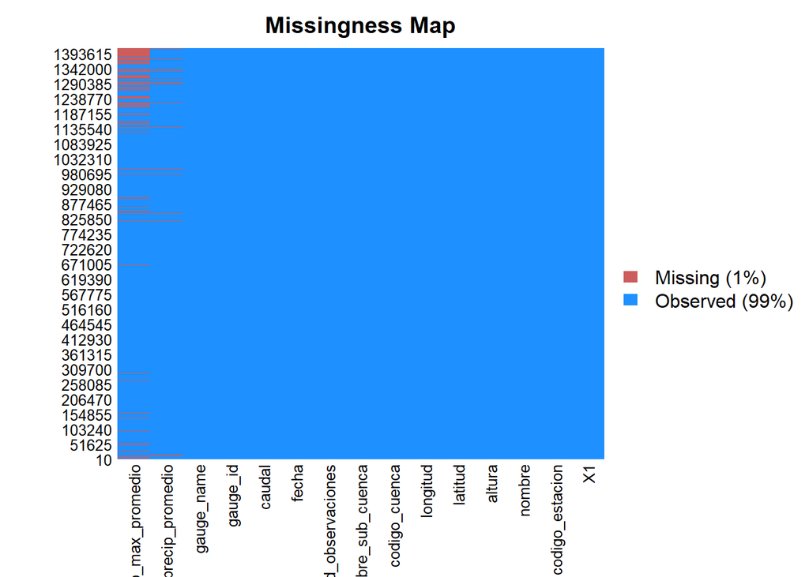

Un 10% de los valores de temperatura maxima promedio son missing data. Esto puede deberse a que (citando al texto guia) ‘pueden haber cuencias sin estaciones de temperatura o precipitacion’

```r
sum(is.na(CaudalDF$temp_max_promedio))*100/nrow(CaudalDF)
```

```
## [1] 10.74016
```

El mismo caso anterior pero para la precipitacion promedio, donde el 1.9% son missing data.

```r
sum(is.na(CaudalDF$precip_promedio))*100/nrow(CaudalDF)
```

```
## [1] 1.967644
```

La extension de los missing values alcanza solo hasta un 10%, por lo tanto se establece que es seguro eliminarlos

```r
CaudalDF=na.omit(CaudalDF)
```

### Pregunta 3

Funcion para graficar caudal, precipitacion promedio y temperatura maxima promedio dada cierta estacion y rango de fechas

```r
plot_estaciones_varias_columnas=function(codigo_estacion, fecha_min, fecha_max){

  #Subset en base a argumentos
  SubsetDF=CaudalDF[CaudalDF$codigo_estacion==codigo_estacion &
      CaudalDF$fecha>=as.POSIXct(x=fecha_min, tz='UTC') &
      CaudalDF$fecha<=as.POSIXct(x=fecha_max, tz='UTC'),]

  #Dejar solo informacion necesaria
  SubsetDF=SubsetDF[,c('fecha','caudal','precip_promedio','temp_max_promedio')]

  #Normalizacion por minimo y maximo. Mismo tratamiento para cada columna de dato
  Normalized=as.data.frame(sapply(X=SubsetDF[,-1], FUN=function(x){
    (x-min(x))/(max(x)-min(x))
  }))

  #Agregar fecha
  Normalized$fecha=SubsetDF$fecha

  #Grafico de lineas
  P1=ggplot() +
    geom_line(data=Normalized, aes(x=fecha, y=caudal), color='blue') +
    geom_line(data=Normalized, aes(x=fecha, y=temp_max_promedio), color='green') +
    geom_line(data=Normalized, aes(x=fecha, y=precip_promedio), color='orange')

  return(P1)

}
```

Probar funcion

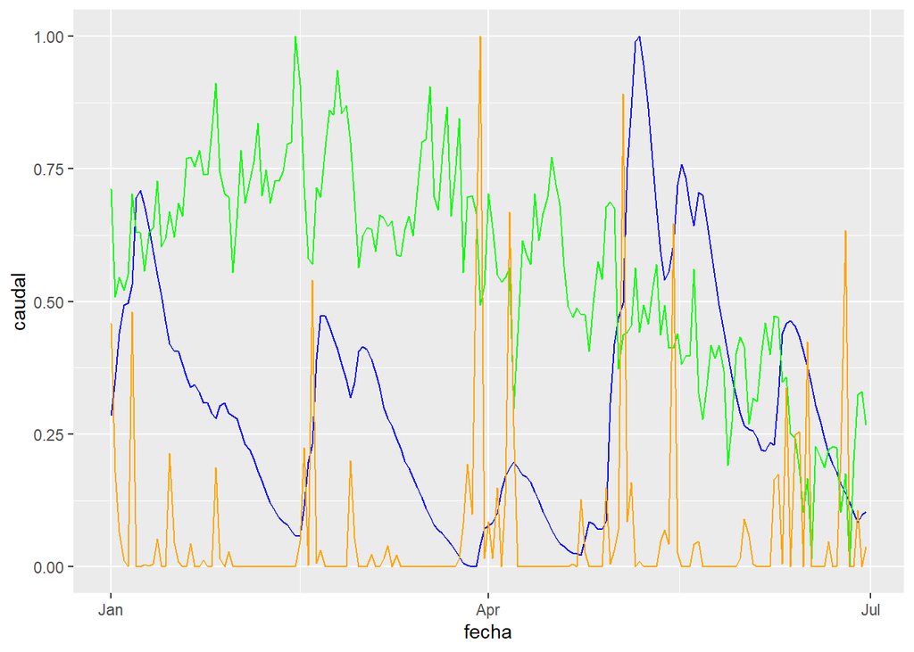

```r
plot_estaciones_varias_columnas(codigo_estacion='11335002',
  fecha_min='2017-01-01', fecha_max='2017-07-01')
```

### Pregunta 4

Generar variables

```r
CaudalDF$caudal_extremo=0
CaudalDF$temp_extremo=0
CaudalDF$precip_extremo=0
```

Obtener percentil 95 por estacion del año para caudal temperatura y precipitacion

```r
UniqueYear=sort(unique(format(x=CaudalDF$fecha, '%Y')))
for(i in 1:length(UniqueYear)){

  #El verano comienza en diciembre del año anterior y continua al año siguiente
  #Si i es igual al total de años, evitar que busque en un año que no existe
  if(i!=length(UniqueYear)){
    #### Verano
    #Buscar meses que corresponden a verano para cada año
    VeranoMax=CaudalDF[CaudalDF$fecha >
        as.POSIXct(x=paste0(UniqueYear[i],'-12-22'), tz='UTC') &
        CaudalDF$fecha <=
        as.POSIXct(x=paste0(UniqueYear[i+1],'-03-20'), tz='UTC'),]

    if(nrow(VeranoMax)!=0){
      #Obtener valores extremos sobre el percentil 95 y extraer ID unica para cada variable
      IDNumCaudal=VeranoMax[which(VeranoMax$caudal>=quantile(x=VeranoMax$caudal, c(.95))),]$X1
      IDNumTemp=VeranoMax[which(VeranoMax$temp_max_promedio>=quantile(x=VeranoMax$temp_max_promedio, c(.95))),]$X1
      IDNumPrecip=VeranoMax[which(VeranoMax$precip_promedio>=quantile(x=VeranoMax$precip_promedio, c(.95))),]$X1

      #Anotar en tabla original basandose en ID unica
      CaudalDF[CaudalDF$X1 %in% IDNumCaudal,]$caudal_extremo=1
      CaudalDF[CaudalDF$X1 %in% IDNumTemp,]$temp_extremo=1
      CaudalDF[CaudalDF$X1 %in% IDNumPrecip,]$precip_extremo=1
    }
  }

  ##### Invierno
  #Buscar meses que corresponden a invierno para cada año
  InviernoMax=CaudalDF[CaudalDF$fecha >=
      as.POSIXct(x=paste0(UniqueYear[i],'-06-21'), tz='UTC') &
      CaudalDF$fecha <
      as.POSIXct(x=paste0(UniqueYear[i],'-09-23'), tz='UTC'),]

  if(nrow(InviernoMax)!=0){
    #Obtener valores extremos sobre el percentil 95 y extraer ID unica para cada variable
    IDNumCaudal=InviernoMax[which(InviernoMax$caudal>=quantile(x=InviernoMax$caudal, c(.95))),]$X1
    IDNumTemp=InviernoMax[which(InviernoMax$temp_max_promedio>=quantile(x=InviernoMax$temp_max_promedio, c(.95))),]$X1
    IDNumPrecip=InviernoMax[which(InviernoMax$precip_promedio>=quantile(x=InviernoMax$precip_promedio, c(.95))),]$X1

    #Anotar en tabla original basandose en ID unica
    CaudalDF[CaudalDF$X1 %in% IDNumCaudal,]$caudal_extremo=1
    CaudalDF[CaudalDF$X1 %in% IDNumTemp,]$temp_extremo=1
    CaudalDF[CaudalDF$X1 %in% IDNumPrecip,]$precip_extremo=1
  }

  ##### Primavera
  #Buscar meses que corresponden a invierno para cada año
  PrimaveraMax=CaudalDF[CaudalDF$fecha >=
      as.POSIXct(x=paste0(UniqueYear[i],'-09-23'), tz='UTC') &
      CaudalDF$fecha <=
      as.POSIXct(x=paste0(UniqueYear[i],'-12-22'), tz='UTC'),]

  if(nrow(PrimaveraMax)!=0){
    #Obtener valores extremos sobre el percentil 95 y extraer ID unica para cada variable
    IDNumCaudal=PrimaveraMax[which(PrimaveraMax$caudal>=quantile(x=PrimaveraMax$caudal, c(.95))),]$X1
    IDNumTemp=PrimaveraMax[which(PrimaveraMax$temp_max_promedio>=quantile(x=PrimaveraMax$temp_max_promedio, c(.95))),]$X1
    IDNumPrecip=PrimaveraMax[which(PrimaveraMax$precip_promedio>=quantile(x=PrimaveraMax$precip_promedio, c(.95))),]$X1

    #Anotar en tabla original basandose en ID unica
    CaudalDF[CaudalDF$X1 %in% IDNumCaudal,]$caudal_extremo=1
    CaudalDF[CaudalDF$X1 %in% IDNumTemp,]$temp_extremo=1
    CaudalDF[CaudalDF$X1 %in% IDNumPrecip,]$precip_extremo=1
  }

  #Otono
  #Buscar meses que corresponden a invierno para cada año
  OtonoMax=CaudalDF[CaudalDF$fecha >
      as.POSIXct(x=paste0(UniqueYear[i],'-03-20'), tz='UTC') &
      CaudalDF$fecha <
      as.POSIXct(x=paste0(UniqueYear[i],'-06-21'), tz='UTC'),]

  if(nrow(OtonoMax)!=0){
    #Obtener valores extremos sobre el percentil 95 y extraer ID unica para cada variable
    IDNumCaudal=OtonoMax[which(OtonoMax$caudal>=quantile(x=OtonoMax$caudal, c(.95))),]$X1
    IDNumTemp=OtonoMax[which(OtonoMax$temp_max_promedio>=quantile(x=OtonoMax$temp_max_promedio, c(.95))),]$X1
    IDNumPrecip=OtonoMax[which(OtonoMax$precip_promedio>=quantile(x=OtonoMax$precip_promedio, c(.95))),]$X1

    #Anotar en tabla original basandose en ID unica
    CaudalDF[CaudalDF$X1 %in% IDNumCaudal,]$caudal_extremo=1
    CaudalDF[CaudalDF$X1 %in% IDNumTemp,]$temp_extremo=1
    CaudalDF[CaudalDF$X1 %in% IDNumPrecip,]$precip_extremo=1
  }

}
```

Otra variable para definir climas extremos seria tomar los valores mas extremos (altos y bajos) considerando la data historica anual completa. En vez de ver el percentil 95 por año, considerar los ultimos 10 o 20 años y considerar los maximos y minimos para cada variable como extremos

### Pregunta 5

Calcular promedio de caudal extremo y su desviacion estandar

```r
CuencaCaudal=aggregate(x=CaudalDF[,c('caudal_extremo')], by=list(CaudalDF$codigo_cuenca), FUN=function(x){
  c("Mean"=mean(x, na.rm=TRUE), 'SD'=sd(x, na.rm=TRUE))
})
```

Almacenar codigo de cuenta antes de modificar la tabla resultante

```r
CuencaID=CuencaCaudal$Group.1
```

Pasar resultado a tabla

```r
CuencaCaudal=as.data.frame(CuencaCaudal$caudal_extremo)
```

Agregar codigo de cuenca como factor

```r
CuencaCaudal$CuencaID=as.factor(CuencaID)
```

Graficar – Existen diferencias de niveles extremos de caudales entre las distintas cuencas. Ademas de eso, como los promedios ignoran el año, se puede decir que una misma cuenca ha sufrido muchas variaciones en los niveles extremos de caudales.

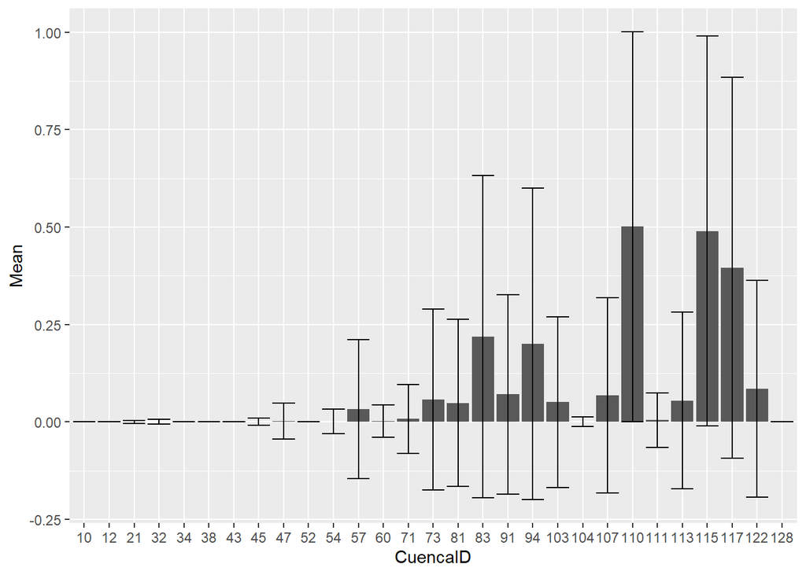

```r
ggplot(data=CuencaCaudal, aes(x=CuencaID, y=Mean)) + geom_col() +
  geom_errorbar(aes(ymin=Mean-SD, ymax=Mean+SD))
```

### Pregunta 6

Calcular valores acumulativos para cada parametro extremo

```r
CaudalDF$Caudal_Acumulativo=cumsum(x=CaudalDF$caudal_extremo)
CaudalDF$Temp_Acumulativo=cumsum(x=CaudalDF$temp_extremo)
CaudalDF$Precip_Acumulativo=cumsum(x=CaudalDF$precip_extremo)
```

Generar graficos

```r
P1=ggplot() + geom_line(data=CaudalDF, aes(x=fecha, y=Caudal_Acumulativo), color='blue')
P2=ggplot() + geom_line(data=CaudalDF, aes(x=fecha, y=Temp_Acumulativo), color='green')
P3=ggplot() + geom_line(data=CaudalDF, aes(x=fecha, y=Precip_Acumulativo), color='orange')
```

Grilla con graficos – los eventos extremos son mas comunes ahora. La linea no muestra un plateau, no se mantiene, al contrario, solo sigue creciendo.

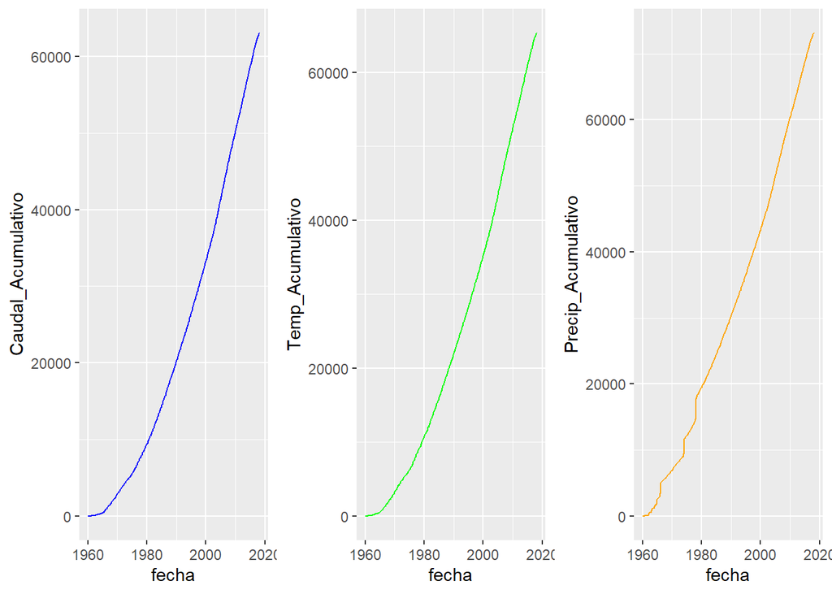

```r
plot_grid(plotlist=list(P1,P2,P3), nrow=1, ncol=3)
```

### Pregunta 7

Calcular promedio de caudal en fechas que son iguales

```r
CaudalMean=aggregate(x=CaudalDF[,c('caudal')], by=list(CaudalDF$fecha), FUN=mean)
```

Se observa una tendencia anual

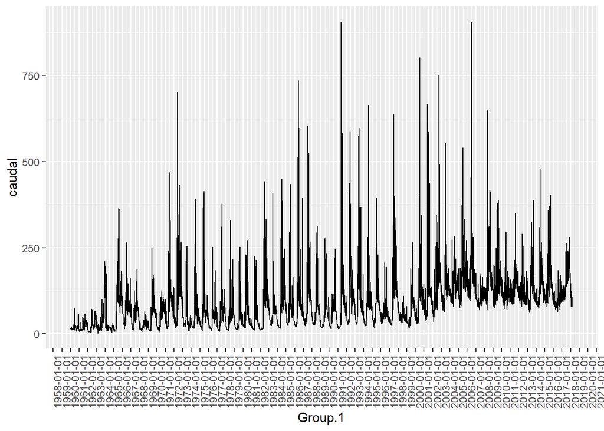

```r
ggplot() + geom_line(data=CaudalMean, aes(x=Group.1, y=caudal, group=1)) +
  scale_x_datetime(date_breaks='1 years') +
  theme(axis.text.x=element_text(angle=90, hjust=1))
```

Remover variables acumulativas y de nombres

```r
CaudalDF$Precip_Acumulativo=NULL
CaudalDF$Temp_Acumulativo=NULL
CaudalDF$Caudal_Acumulativo=NULL
CaudalDF$nombre=NULL
CaudalDF$nombre_sub_cuenca=NULL
CaudalDF$gauge_name=NULL
```

Generar Train y test set. Se tomara el 70% de los datos para entrenar el modelo y el 30% para probar el modelo. Si se tiene en consideracion la temporalidad, lo mas coherente es tomar la primera porcion como entrenamiento (fechas mas antiguas) y la segunda como prueba. La segunda porcion (fechas mas recientes) serian datos del ‘futuro’.

Generar Test y Train set.

```r
TrainDF=CaudalDF[1:floor(nrow(CaudalDF)*70/100),]
TestDF=CaudalDF[(floor(nrow(CaudalDF)*70/100)+1):nrow(CaudalDF),]
```

Entrenar modelo en base al caudal y precipitaciones. Con este modelo se pretende poder predecir caudales extremos en base a precipitaciones. Como las precipitaciones se estiman con datos meteorologicos, es posible predecir un evento de caudal extremo. Tomar solo precipitaciones es una solucion razonable en terminos de obtencion de datos. Seria posible usar tambien informacion del caudal, sin embargo no seria logico y promueve el overfitting (debido a que se esta prediciendo un caudal extremo en base al caudal mismo).

```r
ModelTemp=lm(formula=caudal_extremo ~ precip_promedio + precip_extremo, data=TrainDF)
summary(ModelTemp)
```

```
##
## Call:
## lm(formula = caudal_extremo ~ precip_promedio + precip_extremo,
##     data = TrainDF)
##
## Residuals:
##      Min       1Q   Median       3Q      Max
## -0.77284 -0.04288 -0.04288 -0.04288  0.95712
##
## Coefficients:
##                  Estimate Std. Error t value Pr(>|t|)
## (Intercept)     4.288e-02  2.403e-04  178.45   <2e-16 ***
## precip_promedio 3.077e-03  3.887e-05   79.17   <2e-16 ***
## precip_extremo  2.376e-02  1.235e-03   19.25   <2e-16 ***
## ---
## Signif. codes:  0 '***' 0.001 '**' 0.01 '*' 0.05 '.' 0.1 ' ' 1
##
## Residual standard error: 0.2169 on 879531 degrees of freedom
## Multiple R-squared:  0.01581,    Adjusted R-squared:  0.01581
## F-statistic:  7064 on 2 and 879531 DF,  p-value: < 2.2e-16
```

Este modelo podria utilizarse tomando datos de estaciones meteorologicas, en conjunto con (o provistos por) la Direccion Meteorologica de Chile

### Pregunta 8

## Pregunta 8A

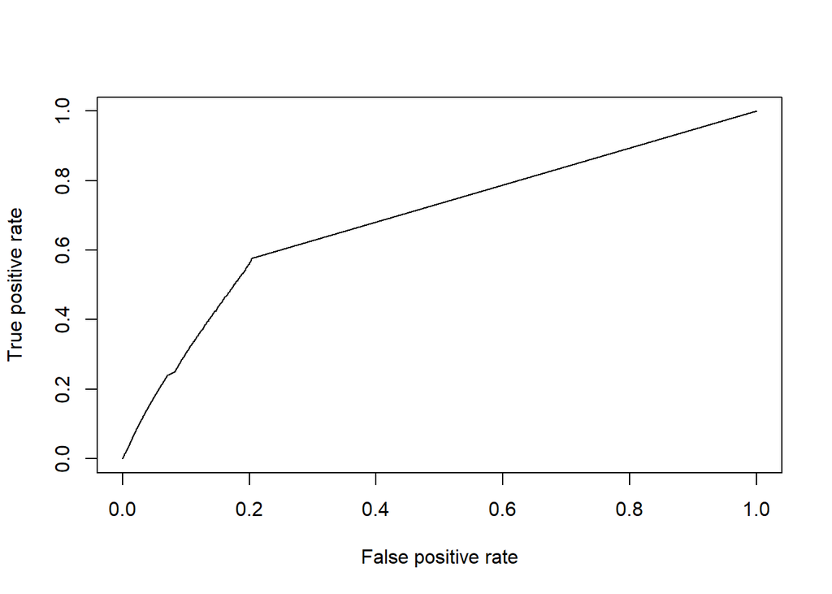

```r
PredROC=prediction(predict(ModelTemp), TrainDF$caudal_extremo)
plot(performance(PredROC, 'tpr', 'fpr'))
```

Predict values

```r
Predicted=predict(object=ModelTemp, newdata=TestDF)
```

Confussion Matrix – Accuracy 0.95 – Recall 0.95

```r
PredictedTreshold=ifelse(test=Predicted>=0.5, yes=1, no=0)
confusionMatrix(as.factor(TestDF$caudal_extremo),
  as.factor(PredictedTreshold), mode = "prec_recall")
```

```
## Confusion Matrix and Statistics
##
##           Reference
## Prediction      0      1
##          0 358110      5
##          1  18829      0
##
##                Accuracy : 0.95
##                  95% CI : (0.9493, 0.9507)
##     No Information Rate : 1
##     P-Value [Acc > NIR] : 1
##
##                   Kappa : 0
##
##  Mcnemar's Test P-Value : <2e-16
##
##               Precision : 1.0000
##                  Recall : 0.9500
##                      F1 : 0.9744
##              Prevalence : 1.0000
##          Detection Rate : 0.9500
##    Detection Prevalence : 0.9500
##       Balanced Accuracy : 0.4750
##
##        'Positive' Class : 0
##
```

Resample RMSE de 0.21, pequeno para un rango de variable dependiente que va de 0 a 1

```r
postResample(pred=Predicted, obs=TestDF$caudal_extremo)
```

```
##       RMSE   Rsquared        MAE
## 0.21710121 0.00750436 0.09392302
```

Variables importantes Rehacer modelo con todas las variables para ver cuales son las mas importantes

```r
ModelVar=lm(formula=caudal_extremo ~ ., data=TrainDF)
summary(ModelVar)
```

```
##
## Call:
## lm(formula = caudal_extremo ~ ., data = TrainDF)
##
## Residuals:
##     Min      1Q  Median      3Q     Max
## -7.4541 -0.0371 -0.0112  0.0087  0.9893
##
## Coefficients: (1 not defined because of singularities)
##                          Estimate Std. Error t value Pr(>|t|)
## (Intercept)            -1.553e+00  2.988e-02 -51.954  < 2e-16 ***
## X1                      3.682e-09  4.663e-10   7.896 2.87e-15 ***
## codigo_estacion        -9.732e-10  6.726e-10  -1.447    0.148
## altura                  1.533e-05  3.671e-07  41.754  < 2e-16 ***
## latitud                 2.467e-03  1.505e-04  16.390  < 2e-16 ***
## longitud               -2.282e-02  4.176e-04 -54.637  < 2e-16 ***
## codigo_cuenca           4.591e-04  5.338e-05   8.601  < 2e-16 ***
## cantidad_observaciones -1.069e-06  2.625e-08 -40.724  < 2e-16 ***
## fecha                  -3.997e-11  5.091e-13 -78.509  < 2e-16 ***
## caudal                  5.357e-04  7.530e-07 711.433  < 2e-16 ***
## gauge_id                       NA         NA      NA       NA
## precip_promedio        -8.016e-04  3.086e-05 -25.977  < 2e-16 ***
## temp_max_promedio       1.193e-03  3.065e-05  38.939  < 2e-16 ***
## temp_extremo           -6.889e-03  8.480e-04  -8.123 4.54e-16 ***
## precip_extremo          3.142e-02  9.447e-04  33.264  < 2e-16 ***
## ---
## Signif. codes:  0 '***' 0.001 '**' 0.01 '*' 0.05 '.' 0.1 ' ' 1
##
## Residual standard error: 0.1642 on 879520 degrees of freedom
## Multiple R-squared:  0.436,  Adjusted R-squared:  0.436
## F-statistic: 5.23e+04 on 13 and 879520 DF,  p-value: < 2.2e-16
```

## Pregunta 8B

En este notebook se dividio la informacion para entrenar el modelo, dejando un 70% de los datos. Si se capturan 70% de los eventos de caudales, seria equivalente a set de entrenamiento utilizado en este documento y la precision seria la misma.